# Predict431-TS1

```r
setwd("C:/Users/Admin/Dropbox/Northwestern University/Predict413/Assignment 1/")

da <- read.table("m-ge3dx8113.txt",header=T)
head(da)
```

```
##   PERMNO     date        ge    vwretd    ewretd    sprtrn
## 1  12060 19810130  0.000000 -0.040085  0.005615 -0.045742
## 2  12060 19810227  0.089796  0.015521  0.002150  0.013277
## 3  12060 19810331  0.014981  0.046184  0.072674  0.036033
## 4  12060 19810430 -0.020522 -0.011268  0.027885 -0.023456
## 5  12060 19810529  0.001905  0.013551  0.027187 -0.001657
## 6  12060 19810630 -0.046768 -0.010242 -0.013194 -0.010408
```

- **PERMNO**: CRSP 5-digit integer for all common securities
- **date**: yearmonthday as, e.g., 20150131
- **ge**: General Electric company stock code
- **vwretd**: CRSP value-weighted index
- **ewretd**: CRSP equal-weighted index
- **sprtrn**: S&P composite index

Your objective is to explore the relationship among the variables, identify what types of data each variable is, and respond to each part in the Procedure Section that follows.

### EDA (1 point)

Consider the monthly log returns of GE stock from January 1981 to December 2013. The original data are monthly returns for General Electric (GE) stock, CRSP valueweighted index (VW), CRSP equal-weighted index (EW), and S&P composite index (SP) from January 1981 to December 2013. The returns include dividend distributions. The data ???le is m-ge3dx8113.txt with column names PERMNO of GE, date, ge, vwretd, ewretd, and sprtrn, respectively.

1. Compute the sample mean, standard deviation, skewness, excess kurtosis, minimum, and maximum of each untransformed simple return series. What do these statistics tell you?

```r
library("fBasics")


# basicStats(da$ge)
# basicStats(da$vwretd)
# basicStats(da$ewretd)
# basicStats(da$sprtrn)


basicStats_da <- basicStats(da)

library("knitr","xtable")

kable(basicStats_da[c('Mean', 'Stdev', 'Skewness', 'Kurtosis', 'Minimum', 'Maximum'), -(1:2)], format="pandoc", caption="Basic Statistics of the monthly returns-Original")
```

Basic Statistics of the monthly returns-Original

|  | ge | vwretd | ewretd | sprtrn |
| --- | --- | --- | --- | --- |
| Mean | 0.012900 | 0.009698 | 0.011022 | 0.007594 |
| Stdev | 0.071073 | 0.045036 | 0.053461 | 0.043921 |
| Skewness | -0.226160 | -0.780736 | -0.499120 | -0.658830 |
| Kurtosis | 1.373376 | 2.526277 | 3.259182 | 2.204877 |
| Minimum | -0.272877 | -0.225363 | -0.272248 | -0.217630 |
| Maximum | 0.251236 | 0.128496 | 0.225012 | 0.131767 |

2. Transform the simple returns to log returns (e.g., ln(ge)). Compute the sample mean, standard deviation, skewness, excess kurtosis, minimum, and maximum of each log return series. Interpret and compare to the untransformed statistics above.

```r
# natural logarithm
log_da = log(da[,-(1:2)]+1)  # Transform the simple returns to log returns. We have negative values, +1 to make sure base in log are positive

basicStats_log_da <- basicStats(log_da)


kable(basicStats_log_da[c('Mean', 'Stdev', 'Skewness', 'Kurtosis', 'Minimum', 'Maximum'), ], format="pandoc", caption="Basic Statistics of the monthly  returns- Log Tranformation")
```

Basic Statistics of the monthly returns- Log Tranformation

[output not shown]

```r
t.test(log_da$ge)
```

```
##
##  One Sample t-test
##
## data:  log_da$ge
## t = 2.8708, df = 395, p-value = 0.004315
## alternative hypothesis: true mean is not equal to 0
## 95 percent confidence interval:
##  0.003248467 0.017365132
## sample estimates:
## mean of x
## 0.0103068
```

4. What are the pairwise associations between the variables? Interpret.

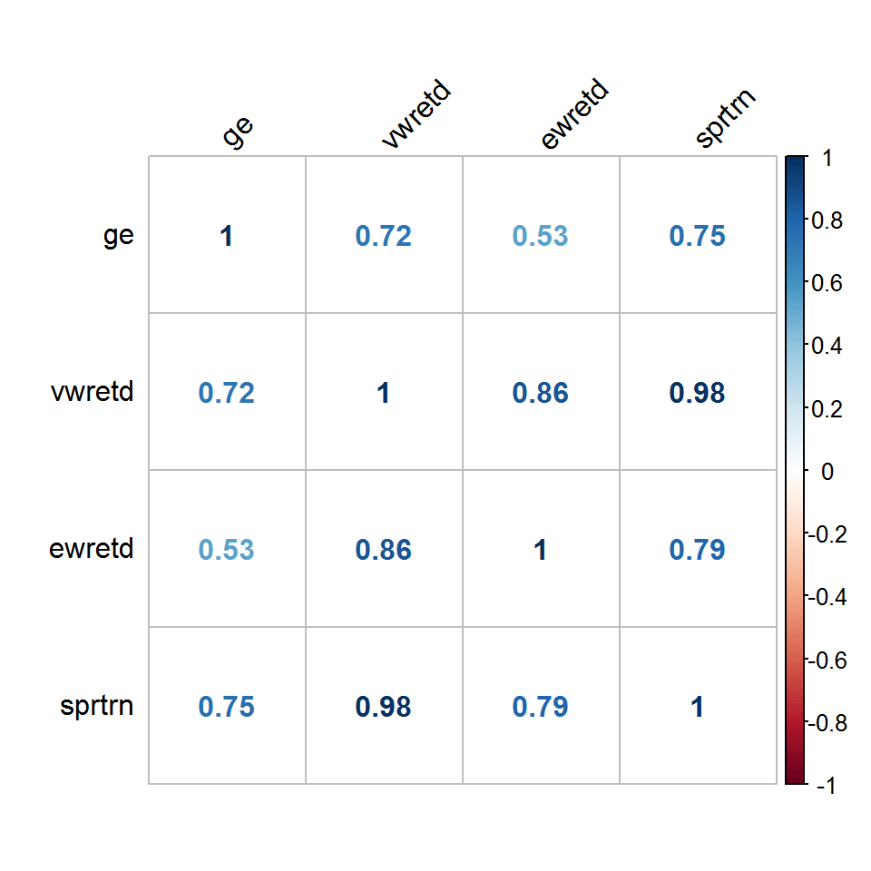

```r
# Correlations

library(dplyr)
da.cor <- da %>%
  dplyr::select(ge:sprtrn) %>%
  cor(use = "pairwise.complete.obs")

library(corrplot)
corrplot(da.cor, type = "full", method = "number", tl.srt=45, tl.col = "black", title = "")
```

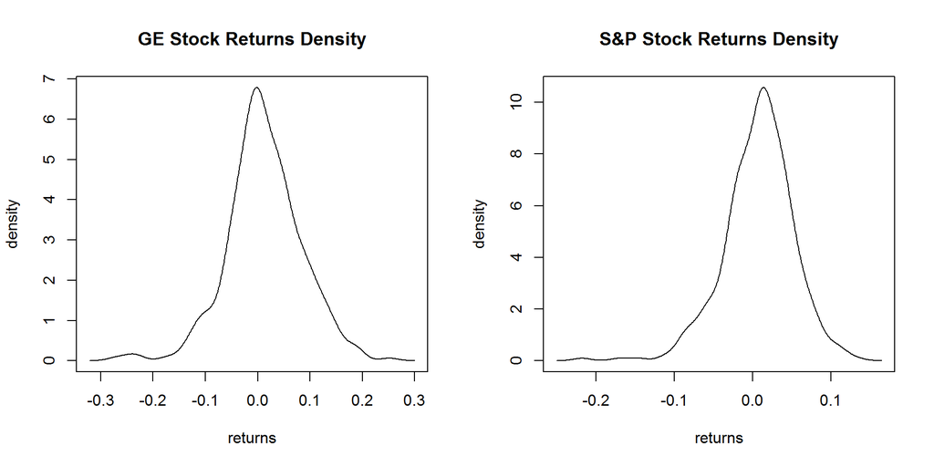

```r
d1=density(da$ge)
d2=density(da$sprtrn)

par(mfcol=c(1,2))
plot(d1$x,d1$y,xlab='returns',ylab='density',main="GE Stock Returns Density",type='l')
plot(d2$x,d2$y,xlab='returns',ylab='density',main="S&P Stock Returns Density",type='l')
```

2. Hypothesis tests (1 point) Consider again the monthly log returns of GE stock from January 1981 to December 2013. The original data are monthly returns for General Electric (GE) stock, CRSP value-weighted index (VW), CRSP equal-weighted index (EW), and S&P composite index (SP) from January 1981 to December 2013. The returns include dividend distributions. The data ???le is m-ge3dx8113.txt with column names PERMNO of GE, date, ge, vwretd, ewretd, and sprtrn, respectively. Perform the following and draw conclusions using the 5% signi???cance level.
1. Construct a 95% con???dence interval for the monthly log returns of GE stock.

```r
t.test(da$ge)   # the 95% confidence interval will be appeared in the result
```

```
##
##  One Sample t-test
##
## data:  da$ge
## t = 3.6119, df = 395, p-value = 0.0003432
## alternative hypothesis: true mean is not equal to 0
## 95 percent confidence interval:
##  0.005878371 0.019921654
## sample estimates:
##  mean of x
## 0.01290001
```

```r
# Below is how to calcuate 95% CI by hand

error <- qt(0.975,df=length(da$ge)-1)*sd(da$ge)/sqrt(length(da$ge))
error
```

```
## [1] 0.007021641
```

```r
left <- mean(da$ge)-error
left
```

```
## [1] 0.005878371
```

```r
right <- mean(da$ge)+error
right
```

```
## [1] 0.01992165
```

2. Test H0 : m3 = 0 versus Ha : m3 != 0, where m3 denotes the skewness of the return.